# TFLink use case 1

# 4 Transcription factors having up to 50 target genes

To be able to plot all target genes of two transcription factors with readable names, we will narrow down our choices to interactions supported by **small-scale evidences**, and we will select from transcription factor having up-to **50 target genes**.

Therefore, we create a new interaction table containing interaction data supported by small-scale evidences. (Alternatively, this table can also be downloaded directly from the [TFLink](https://tflink.net/download/) website.)

```r
Interaction_tab_SS <- Interaction_tab %>%
  filter(`Small-scale.evidence` == "Yes")
```

Let’s save the names of such transcription factors having up to 50 target genes to a `vector` variable.

```r
TF_names <- Interaction_tab_SS %>%
 group_by(Name.TF) %>%
 summarise(`Nr. of target genes` = n()) %>%
 filter(`Nr. of target genes` < 50) %>%
 select(Name.TF) %>%
 pull()

# Checking the content
head(TF_names)
```

```
## [1] "AATF"   "ABL1"   "AHR"    "AIP"    "AIRE"   "ANKRD1"
```

Then, let’s create a `list` variable containing all target genes of each transcription factors, to be able to find the ones regulating common target genes.

```r
# Creating the list
TGs_per_TFs_list <- Interaction_tab_SS %>%
  filter(Name.TF %in% TF_names) %>%
  select(Name.TF, Name.Target) %>%
  group_by(Name.TF) %>%
  group_split() %>%
  lapply(., pull, var = Name.Target)

# Naming the elements
names(TGs_per_TFs_list) <- TF_names

# Checking the content
head(TGs_per_TFs_list, n = 3)
```

```
## $AATF
## [1] "MYC"    "TP53"   "BAX"    "CDKN1A" "KLKB1"  "KLK3"
##
## $ABL1
##  [1] "JUN"    "TP53"   "BAX"    "CSF1"   "CDKN1A" "BCL2"   "BCL6"   "PIM1"
##  [9] "FOXO3"  "CCND2"
##
## $AHR
##  [1] "AHRR"   "MYC"    "ABCG2"  "MFSD2A" "MT2A"   "IL1B"   "PCNA"   "FOS"
##  [9] "RFC3"   "CYP1A2" "CA9"    "UGT1A6" "UGT1A1" "CCNG2"  "IL13"   "CYP2B6"
## [17] "CYP1B1" "CYP1A1" "IL6"    "ARNT"   "CCND1"  "BRCA1"
```

Let’s check which transcription factor pairs have the most common target genes.

```r
# TF pairs in every combinations
TF_combination_list <- combn(names(TGs_per_TFs_list), 2, simplify = FALSE)

# Nr. of common genes of all TF pairs
Intersect_lengths <- list()
for(i in 1:length(TF_combination_list)){
   Intersect_lengths[i] <-
     intersect(TGs_per_TFs_list[[TF_combination_list[[i]][1]]],
               TGs_per_TFs_list[[TF_combination_list[[i]][2]]]) %>%
     length()
}
rm(i)

# Converting list to vector
Intersect_lengths <- Intersect_lengths %>%
  unlist()

# Adding names of TF pairs (separated by "_")
names(Intersect_lengths) <- sapply(TF_combination_list, paste, collapse = "_")

# Checking the maximum number of common genes
Intersect_lengths %>%
  sort() %>%
  tail()
```

```
##   NR1H2_NR1H3    FOSL2_JUND  DNMT1_DNMT3B SREBF1_SREBF2 TWIST1_TWIST2
##            16            17            19            19            25
## STAT5A_STAT5B
##            30
```

Let’s create a `vector` containing the names of the transcription factor pair having the most common target genes.

```r
TFs <- which.max(Intersect_lengths) %>%
  names() %>%
  str_split(pattern = "_") %>%
  unlist()

# Let's see
TFs
```

```
## [1] "STAT5A" "STAT5B"
```

**STAT5A** and **STAT5B** (*signal transducer and activator of transcription 5* *A* and *B*) are two highly similar transcription factors. The **STAT5** proteins are involved in cytosolic signalling and they mediate the expression of specific genes (Nosaka et al. 1999).

# 5 Network visualization of the two transcription factors having the most common target genes

# 6 Using the `igraph` `R` package

Now we need more steps to create an *adjacency matrix* input for the `igraph` network plot.

*Adjacency matrix* is a square matrix used to represent a finite graph. The elements of the matrix indicate whether pairs of vertices are adjacent or not in the graph.

```r
# Creating data.frame
# while excluding target genes with missing names ("-")
Wide_selected_Interaction_tab_SS <- Interaction_tab_SS %>%
  filter(Name.TF %in% TFs & Name.Target != "-") %>%
  select(Name.TF, Name.Target) %>%
  mutate(Value = 1) %>%
  pivot_wider(names_from = Name.Target, values_from = Value) %>%
  replace(is.na(.), 0) %>%
  data.frame()

# Adding row names
rownames(Wide_selected_Interaction_tab_SS) <- Wide_selected_Interaction_tab_SS$Name.TF
Wide_selected_Interaction_tab_SS$Name.TF <- NULL

# Converting to matrix
Wide_selected_Interaction_tab_SS <- Wide_selected_Interaction_tab_SS %>%
  as.matrix()

# We need a function for creating the (symmetrical) adjacency matrix
expand.matrix <- function(A){
  m <- nrow(A)
  n <- ncol(A)
  B <- matrix(0,nrow = m, ncol = m)
  C <- matrix(0,nrow = n, ncol = n)
  cbind(rbind(B,t(A)),rbind(A,C))
}

# Applying the expand.matrix function
Wide_selected_Interaction_tab_SS <- Wide_selected_Interaction_tab_SS %>%
  expand.matrix()

# Adding missing row names
rownames(Wide_selected_Interaction_tab_SS)[1:2] <- colnames(
  Wide_selected_Interaction_tab_SS)[1:2]

# Converting to symmetrical adjacency matrix to asymmetrical to be able to
# create a directed graph (by deleting values below diagonal)
Wide_selected_Interaction_tab_SS[lower.tri(Wide_selected_Interaction_tab_SS)] <- 0L
```

Let’s see how does the resulted *adjacency matrix* looks like by checking its upper left part.

```r
Wide_selected_Interaction_tab_SS[1:10, 1:10]
```

```
##         STAT5A STAT5B PIM1 PTTG1IP MET BCL2L1 IFNG FCGR1A CCND2 CEL
## STAT5A       0      0    1       1   1      1    1      1     1   1
## STAT5B       0      0    1       1   1      1    1      1     0   1
## PIM1         0      0    0       0   0      0    0      0     0   0
## PTTG1IP      0      0    0       0   0      0    0      0     0   0
## MET          0      0    0       0   0      0    0      0     0   0
## BCL2L1       0      0    0       0   0      0    0      0     0   0
## IFNG         0      0    0       0   0      0    0      0     0   0
## FCGR1A       0      0    0       0   0      0    0      0     0   0
## CCND2        0      0    0       0   0      0    0      0     0   0
## CEL          0      0    0       0   0      0    0      0     0   0
```

Let’s create the `igraph` plot.

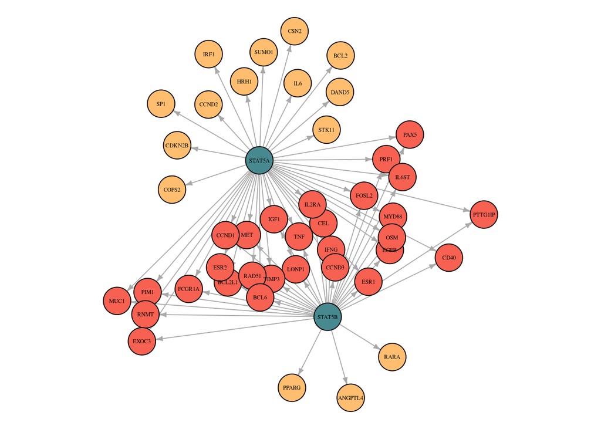

```r
library(igraph)

# Creating the igraph variable
Network <- graph_from_adjacency_matrix(Wide_selected_Interaction_tab_SS,
                                       mode = "directed", diag = FALSE)
# Creating a vector containing three colours for vertices
Vcol <- case_when(colSums(Wide_selected_Interaction_tab_SS[1:2,]) == 0 ~ "#488990",
          colSums(Wide_selected_Interaction_tab_SS[1:2,]) == 1 ~ "#ffbe6f",
          colSums(Wide_selected_Interaction_tab_SS[1:2,]) == 2 ~ "#f66151")

# Reducing the margins of the plot
par(mar = rep(0.1, 4))

# Setting a random seed to reproduce the very same graph over and over again
set.seed(1)

# Creating the plot itself
plot.igraph(Network, layout = layout_with_dh,
            vertex.color = Vcol, vertex.label.color = "black",
            vertex.label.cex = 0.4, edge.arrow.size = 0.4)
```

The two transcription factors are shown with green, their common target genes with red and their distinct target genes with yellow vertices.

To avoid such overlapping among vertices we can adjust the network by hand using the `tkplot` function of the `igraph` package.

```r
set.seed(1)
tkplot(Network, layout = layout_with_dh,
       vertex.color = Vcol, vertex.label.color = "black",
       vertex.label.cex = 0.4)
```

After adjusting the common vertices by hand to avoid overlapping, we can produce a similar image.

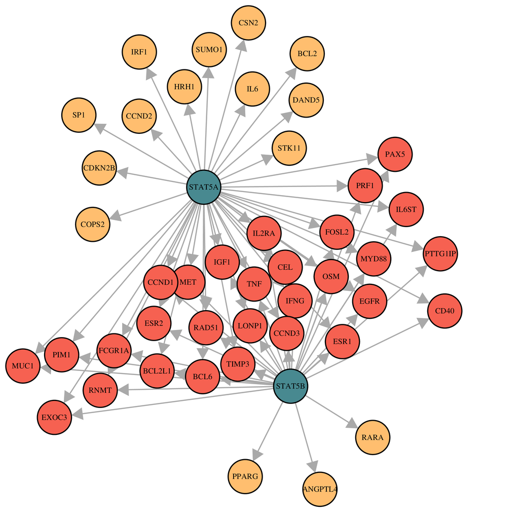

# 7 Using the [Cytoscape](https://cytoscape.org/) software

After all these steps we will end up a transcription factor - target gene interaction network like this:

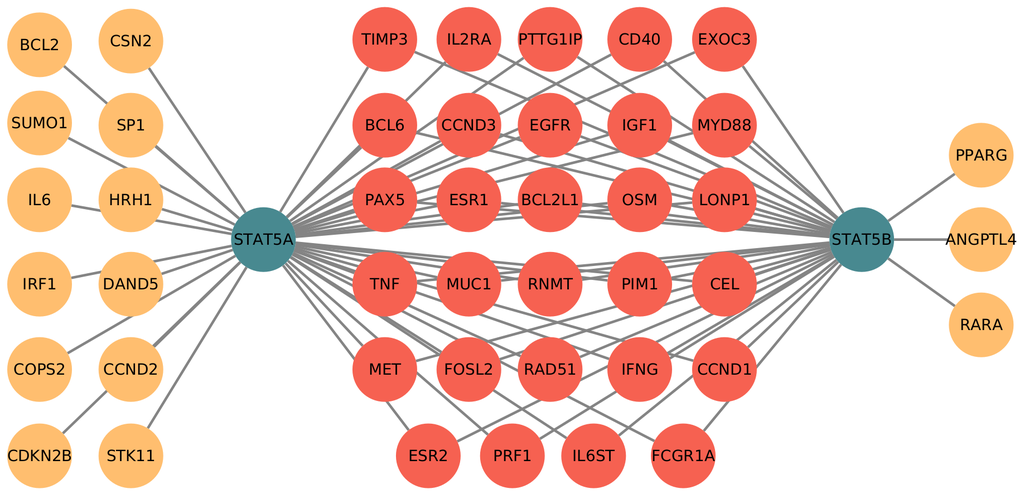

# 8 Environment

In this *use case* the following software and package versions were applied:

- `R` version 4.1.3
- `tidyverse` version 1.3.1
- `data.table` version 1.14.2
- `igraph` version 1.2.11
- `Cytoscape` version 3.8.2

# References

Nosaka, T, T Kawashima, K Misawa, K Ikuta, A L Mui, and T Kitamura. 1999. “Stat5 as a Molecular Regulator of Proliferation, Differentiation and Apoptosis in Hematopoietic Cells.” *The EMBO Journal* 18 (17): 4754–65. https://doi.org/10.1093/emboj/18.17.4754.